# Communicate_Findings_Explanatory slides

## PISA Survey

### Investigation Overview

Are there differences in achievement based on gender, location, wealth, or student attitudes?

Does there exist inequality in academic achievement?

### Dataset Overview

I choose **PISA** Dataset to analyze. PISA is a survey of students' skills and knowledge as they approach the end of compulsory education. It is not a conventional school test. Rather than examining how well students have learned the school curriculum, it looks at how well prepared they are for life beyond school.

Around 510,000 students in 65 economies took part in the PISA 2012 assessment of reading, mathematics and science representing about 28 million 15-year-olds globally. Of those economies, 44 took part in an assessment of creative problem solving and 18 in an assessment of financial literacy.

# Who were covered by the survey?

Data represets males and females equally

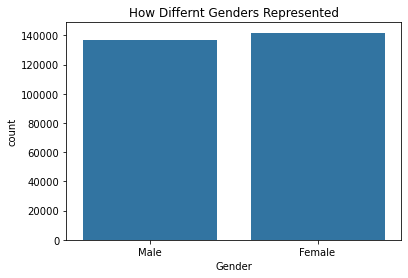

```python
base_color = sb.color_palette()[0]

sb.countplot(data=df1, x='Gender', color=base_color)
plt.title('How Differnt Genders Represented')
```

# From Where?

The break down of the participants are unbalanced. Roughly half of students covered by the survey are participating from Europe and less than 1% from Africa.

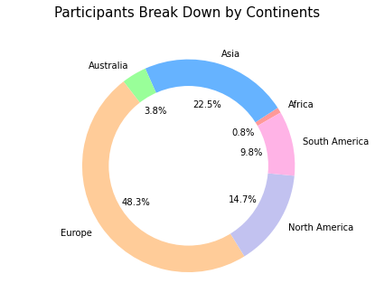

```python
#colors
colors = ['#ff9999','#66b3ff','#99ff99','#ffcc99','#c2c2f0','#ffb3e6']

fig1, ax1 = plt.subplots()
ax1.pie(df3.values, colors = colors, labels=df3.index, autopct='%1.1f%%', startangle=30)
#draw circle
centre_circle = plt.Circle((0,0),0.75,fc='white')
fig = plt.gcf()
fig.gca().add_artist(centre_circle)
# Equal aspect ratio ensures that pie is drawn as a circle
ax1.axis('equal')
plt.tight_layout()
plt.title('Participants Break Down by Continents', pad=32, fontsize=15)
plt.show()
#source (https://medium.com/@kvnamipara/a-better-visualisation-of-pie-charts-by-matplotlib-935b7667d77f)
```

# Do they have internet access?

Most of students have internet access

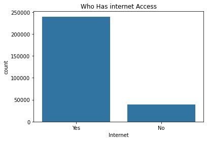

```python
sb.countplot(data=df1, x='Internet', color=base_color)
plt.title('Who Has internet Access');
```

# Do their Fathers have jobs?

Majority of students' fathers have full time jobs.

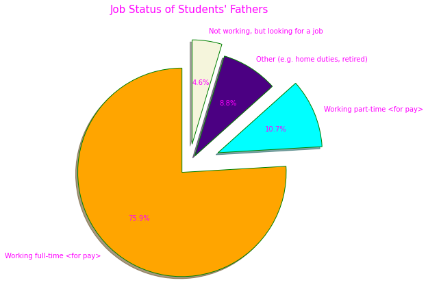

```python
#that was the basic plot in the exploratory stage
#plt.pie(sorted_counts, labels = sorted_counts.index, startangle = 90,counterclock = False);


#this is the basic plot in the explanatory stage

# Creating explode data
explode = (0.1, 0.3, 0.1, 0.2)

colors = ( "orange", "cyan", "indigo", "beige")
# Wedge properties
wp = { 'linewidth' : 1, 'edgecolor' : "green" }

# Creating autocpt arguments
def func(pct, allvalues):
    absolute = int(pct / 100.*np.sum(allvalues))
    return "{:.1f}%".format(pct, absolute)

# Creating plot
fig, ax = plt.subplots(figsize =(10, 7))
wedges, texts, autotexts = ax.pie(sorted_counts,
                                  autopct = lambda pct: func(pct, sorted_counts),
                                  explode = explode,
                                  labels = sorted_counts.index,
                                  shadow = True,
                                  colors = colors,
                                  startangle = 90,
                                  wedgeprops = wp,
                                  textprops = dict(color ="magenta"))

plt.title('Job Status of Students\' Fathers', pad=32, fontsize=15, color = "magenta");

#source (https://www.geeksforgeeks.org/plot-a-pie-chart-in-python-using-matplotlib/)
```

# What are their Mothers Education Levels?

# International Standard Classification of Education

ISCED 0: Early childhood education.

ISCED 1: Primary education.

ISCED 2: Lower secondary education.

ISCED 3: Upper secondary education.

ISCED 4: Post-secondary non-tertiary education.

ISCED 5: Short-cycle tertiary education.

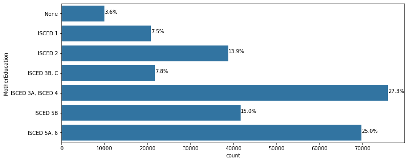

```python
plot_percentage(df1, "MotherEducation");
```

# Wealth vs. Index of Economics Social Cultural Status

The plots reveal a positive correlation between the wealth and the index of economics social cultural status. The overplotting of the scatter plot obscurs the distribution of the data, but this was solved by the 2D histogram. The data seems normalized to me with high concentration points around 0.

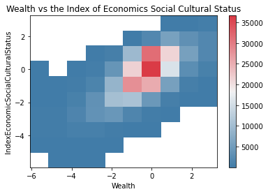

```python
cmap = sb.diverging_palette(240, 10, as_cmap=True)
plt.hist2d(data = df1, x = 'Wealth', y = 'IndexEconomicSocialCulturalStatus', cmin=0.5, cmap=cmap)
plt.colorbar()
plt.xlabel('Wealth')
plt.ylabel('IndexEconomicSocialCulturalStatus');
plt.title('Wealth vs the Index of Economics Social Cultural Status');
#source (https://classroom.udacity.com/nanodegrees/nd002-mena-nfp3/parts/211104e3-a5bc-4247-87b7-06bfa757806c/modules/884648ee-be0a-4bde-853f-26e97458edc8/lessons/22ff3b91-42f7-420e-b6ad-de0b29684ed0/concepts/8f54c142-468e-4e1a-abef-4c6425403a3b)
```

# What is the effect of the wealth on their academic perfornace?

The mode of students grade increases with the wealth consitly till grade 2. Beyond that the behavior is amazing. The best academic performance is achieved by subaverage wealth students. Also, the wealth distribution of the best academic performers is tighter that the rest and centered around -2.

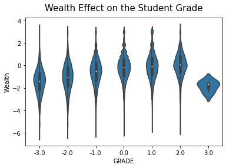

```python
sb.violinplot(data=df1, x='GRADE', y='Wealth',color=base_color, innner=None);
#consistent increase of wealth mode with grades except for the highest grade that is coresponding to the least wealthy people
#distribution is tight, the best academid performance is associated with the least wealthy
plt.title('Wealth Effect on the Student Grade', pad=12, fontsize=15);
```

# Grade vs. Wealth

The students grade increases with the wealth consitly till grade 2. Beyond that the behavior is amazing. The best academic performance is achieved by subaverage wealth students. Also, the wealth distribution of the best academic performers is tighter that the rest and centered around -2. Majority of top academic performance comes from Non-OECD countries.

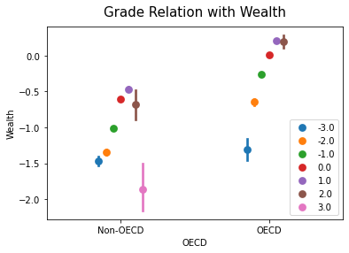

```python
ax = sb.pointplot(data = df1, x = 'OECD', y = 'Wealth', hue = 'GRADE',
                  dodge = 0.3, linestyles = "")
plt.title('Grade Relation with Wealth', pad=12, fontsize=15);
plt.legend(loc='lower right');
```

# How Mothers' Education Affect the students' Grades?

The students grade is increasing consitently woth the mother education level then tends to trail off at the avarage grade. Female students appear to outperform the male students.

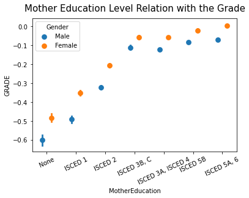

```python
ax = sb.pointplot(data = df1, x = 'MotherEducation', y = 'GRADE', hue = 'Gender',
                  dodge = 0.3, linestyles = "")
plt.title('Mother Education Level Relation with the Grade', pad=12, fontsize=15);
plt.xticks(rotation=25);
```

# Main Takeaways